# HW04_SharvilTurbadkar

## Importing from Google drive

```python
from google.colab import drive
drive.mount('/content/drive')
```

## Importing all the essential Libraries

```python
import numpy as np
import pandas as pd
import pandas_profiling
import seaborn as sns
import matplotlib.pyplot as plt
%matplotlib inline

from sklearn import preprocessing,neighbors
from sklearn.preprocessing import StandardScaler
from sklearn.preprocessing import MinMaxScaler
from sklearn.cluster import KMeans,AgglomerativeClustering
from sklearn.tree import DecisionTreeClassifier
from sklearn.metrics import classification_report,confusion_matrix,precision_score,recall_score,f1_score,r2_score,roc_curve,roc_auc_score
from sklearn.decomposition import PCA
from sklearn.model_selection import train_test_split,GridSearchCV
from sklearn import tree,linear_model
from sklearn import svm
import missingno as mn
from scipy.cluster.hierarchy import dendrogram, linkage

from sklearn import metrics
from sklearn.pipeline import make_pipeline
from sklearn.model_selection import ShuffleSplit
from sklearn.model_selection import cross_val_score

from sklearn.decomposition import PCA
from sklearn.svm import SVC
from sklearn.preprocessing import StandardScaler
from sklearn.pipeline import Pipeline
import pandas as pd
import numpy as np
import matplotlib.pyplot as plt
import seaborn as sns

from sklearn.model_selection import train_test_split, GridSearchCV, cross_val_score, ShuffleSplit
from sklearn import metrics
from sklearn.naive_bayes import GaussianNB, BernoulliNB, MultinomialNB
from sklearn.model_selection import GridSearchCV, StratifiedKFold, train_test_split
from sklearn.linear_model import LogisticRegression

from sklearn import model_selection
from matplotlib.legend_handler import HandlerLine2D
```

## Exploratory Data Analysis

Reading the csv File

```python
data = pd.read_csv("/content/drive/My Drive/Colab Notebooks/Disease Prediction Training-HW04.csv")
```

Making a copy of the file

```python
df=data.copy()
```

```python
df.head()
```

|  | Age | Gender | Height | Weight | High Blood Pressure | Low Blood Pressure | Cholesterol | Glucose | Smoke | Alcohol | Exercise | Disease |
| --- | --- | --- | --- | --- | --- | --- | --- | --- | --- | --- | --- | --- |
| 0 | 59 | female | 167 | 88.0 | 130 | 68 | normal | normal | 0 | 0 | 1 | 0 |
| 1 | 64 | female | 150 | 71.0 | 140 | 100 | normal | normal | 0 | 0 | 0 | 1 |
| 2 | 41 | female | 166 | 83.0 | 100 | 70 | normal | normal | 0 | 1 | 1 | 0 |
| 3 | 50 | male | 172 | 110.0 | 130 | 80 | normal | normal | 1 | 0 | 1 | 0 |
| 4 | 39 | female | 162 | 61.0 | 110 | 80 | high | high | 0 | 0 | 1 | 0 |

```python
df.describe()
```

|  | Age | Height | Weight | High Blood Pressure | Low Blood Pressure | Smoke | Alcohol | Exercise | Disease |
| --- | --- | --- | --- | --- | --- | --- | --- | --- | --- |
| count | 49000.000000 | 49000.000000 | 49000.000000 | 49000.000000 | 49000.000000 | 49000.000000 | 49000.000000 | 49000.000000 | 49000.000000 |
| mean | 52.853306 | 164.366878 | 74.190527 | 128.698939 | 96.917367 | 0.088265 | 0.054245 | 0.803204 | 0.499959 |
| std | 6.763065 | 8.216637 | 14.329934 | 147.624582 | 200.368069 | 0.283683 | 0.226503 | 0.397581 | 0.500005 |
| min | 29.000000 | 55.000000 | 10.000000 | -150.000000 | 0.000000 | 0.000000 | 0.000000 | 0.000000 | 0.000000 |
| 25% | 48.000000 | 159.000000 | 65.000000 | 120.000000 | 80.000000 | 0.000000 | 0.000000 | 1.000000 | 0.000000 |
| 50% | 53.000000 | 165.000000 | 72.000000 | 120.000000 | 80.000000 | 0.000000 | 0.000000 | 1.000000 | 0.000000 |
| 75% | 58.000000 | 170.000000 | 82.000000 | 140.000000 | 90.000000 | 0.000000 | 0.000000 | 1.000000 | 1.000000 |
| max | 64.000000 | 207.000000 | 200.000000 | 14020.000000 | 11000.000000 | 1.000000 | 1.000000 | 1.000000 | 1.000000 |

```python
df.describe().loc['std'][df.describe().loc['std']==0]
```

```
Series([], Name: std, dtype: float64)
```

No Column should be dropped as every column has variance abive zero

Checking the datatypes of the columns

```python
df.dtypes
```

```
Age                      int64
Gender                  object
Height                   int64
Weight                 float64
High Blood Pressure      int64
Low Blood Pressure       int64
Cholesterol             object
Glucose                 object
Smoke                    int64
Alcohol                  int64
Exercise                 int64
Disease                  int64
dtype: object
```

Dropping duplicate entries

```python
df.drop_duplicates(subset=["Age","Gender","Height","Weight","Low Blood Pressure","High Blood Pressure","Cholesterol","Glucose","Smoke","Alcohol","Exercise","Disease"],keep=False,inplace=True)
```

Viewing the correlation of variables

```python
df.corr()
```

|  | Age | Height | Weight | High Blood Pressure | Low Blood Pressure | Smoke | Alcohol | Exercise | Disease |
| --- | --- | --- | --- | --- | --- | --- | --- | --- | --- |
| Age | 1.000000 | -0.080643 | 0.053685 | 0.024297 | 0.015929 | -0.052615 | -0.030096 | -0.012167 | 0.236298 |
| Height | -0.080643 | 1.000000 | 0.293295 | 0.003084 | 0.005832 | 0.190113 | 0.095795 | -0.006803 | -0.009697 |
| Weight | 0.053685 | 0.293295 | 1.000000 | 0.030562 | 0.039863 | 0.054920 | 0.055803 | -0.010102 | 0.173522 |
| High Blood Pressure | 0.024297 | 0.003084 | 0.030562 | 1.000000 | 0.015711 | -0.001968 | 0.000653 | 0.003145 | 0.052782 |
| Low Blood Pressure | 0.015929 | 0.005832 | 0.039863 | 0.015711 | 1.000000 | 0.003566 | 0.011476 | 0.004067 | 0.059733 |
| Smoke | -0.052615 | 0.190113 | 0.054920 | -0.001968 | 0.003566 | 1.000000 | 0.334310 | 0.031877 | -0.025398 |
| Alcohol | -0.030096 | 0.095795 | 0.055803 | 0.000653 | 0.011476 | 0.334310 | 1.000000 | 0.030565 | -0.012761 |
| Exercise | -0.012167 | -0.006803 | -0.010102 | 0.003145 | 0.004067 | 0.031877 | 0.030565 | 1.000000 | -0.024354 |
| Disease | 0.236298 | -0.009697 | 0.173522 | 0.052782 | 0.059733 | -0.025398 | -0.012761 | -0.024354 | 1.000000 |

Making a heatmap of the correlation matrix

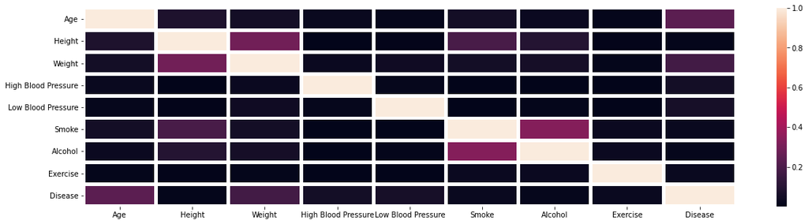

```python
plt.clf()
fig=plt.figure(figsize=(20,5))
sns.heatmap(df.corr().abs(),linecolor='white',fmt='.2g',linewidths=4)
```

```python
df.shape
```

```
(45939, 12)
```

There are no null values

```python
df.isnull().sum()
```

```
Age                    0
Gender                 0
Height                 0
Weight                 0
High Blood Pressure    0
Low Blood Pressure     0
Cholesterol            0
Glucose                0
Smoke                  0
Alcohol                0
Exercise               0
Disease                0
dtype: int64
```

Likeliness of contracting disease increases with Age

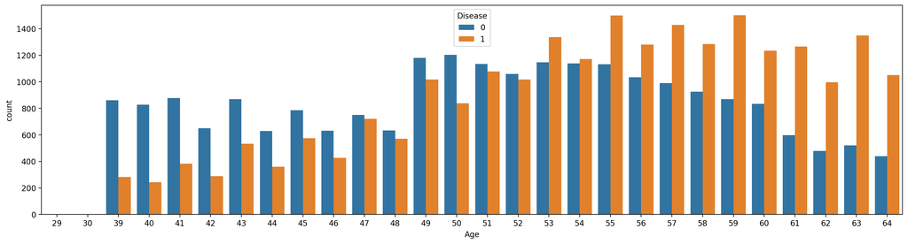

```python
fig=plt.figure(figsize=(20,5),dpi=200)
sns.countplot(x='Age',hue='Disease',data=df)
```

```python
age_labels=['Adult','Old','Very Old']
df['Age']=pd.qcut(df['Age'],3,labels=age_labels)
```

```python
df[['Age','Disease']].groupby('Age').mean().sort_values(by='Disease',ascending=False)
```

| Age | Disease |
| --- | --- |
| Very Old | 0.650558 |
| Old | 0.535805 |
| Adult | 0.386569 |

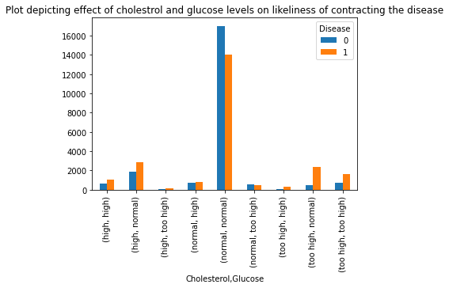

```python
ct=pd.crosstab(columns=df['Disease'],index=[df['Cholesterol'],df['Glucose']]).plot(kind='bar')
plt.title('Plot depicting effect of cholestrol and glucose levels on likeliness of contracting the disease')
```

*From the Above graph we can decipher than likeliness of not being affected by the disease is more when you have normal cholestrol and glucose levels Extreme values render you more vulnerable to the disease*

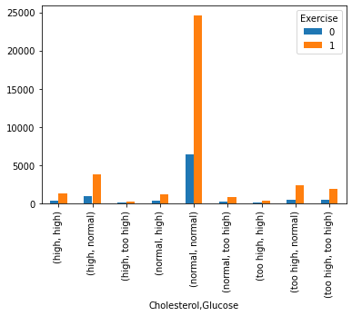

```python
ct=pd.crosstab(columns=df['Exercise'],index=[df['Cholesterol'],df['Glucose']]).plot(kind='bar')
```

*From the graph we infer that people with normal cholestrol and glucose levels tend to exercise more*

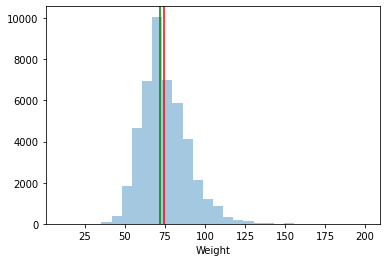

```python
sns.distplot(df['Weight'],kde=False,bins=30)
plt.axvline(df['Weight'].mean(),color='r')
plt.axvline(df['Weight'].median(),color='g')
```

Finding the minimum and maximum values for High and Low blood pressures

```python
print( df['High Blood Pressure'].min())
print( df['Low Blood Pressure'].min())
print(df['High Blood Pressure'].max())
print(df['Low Blood Pressure'].max())
```

```
-150
0
14020
11000
```

```python
(df['High Blood Pressure']<df['Low Blood Pressure']).astype(np.number).sum()
```

```
865.0
```

```python
#Replacing inctances where HBP>LBP
df['High Blood Pressure'],df['Low Blood Pressure']=np.where(df['High Blood Pressure']<df['Low Blood Pressure'],(df['Low Blood Pressure'],df['High Blood Pressure']),(df['High Blood Pressure'],df['Low Blood Pressure']))
```

```python
(df['High Blood Pressure']<df['Low Blood Pressure']).sum()
```

```
0
```

Calculating BMI

```python
df['Height']=df['Height']/100
```

```python
df['BMI']=df['Weight']/(np.power(df['Height'],2))
```

Dropping Height and weight as they are redundant columns and can cause multi-collinearity when BMI is induced in the model

```python
df['BMI'].clip(upper=45)
df['BMI'].clip(lower=15)
df.drop('Height',axis=1,inplace=True)
df.drop('Weight',axis=1,inplace=True)
```

```python
df['BMI_Category']=pd.cut(df['BMI'],bins=[15,23,30,45],labels=['Underweight','Healthy','Overweight'])
```

Thus we conclude that people with high BMI have higher chances of contracting the disease

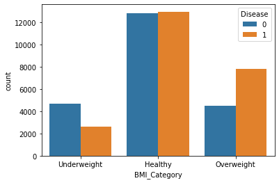

```python
sns.countplot(data=df,x='BMI_Category',hue='Disease')
```

Winsorizing HBP and LBP values

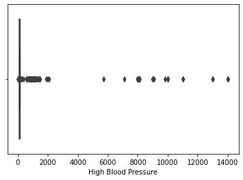

```python
sns.boxplot(df['High Blood Pressure'])
```

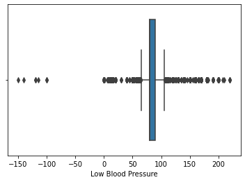

```python
sns.boxplot(df['Low Blood Pressure'])
```

Winsorizing High and Low Blood Pressure as anyone with a blood pressure higher than 250 or lesser has a crdiac arrest and one with lesser than 40 Low blood pressure can deprive your body of enough oxygen to carry out its functions, leading to damage to your heart and brain Thus they are winsorized

```python
df['High Blood Pressure']=df['High Blood Pressure'].clip(upper=250)
df['Low Blood Pressure']=df['Low Blood Pressure'].clip(lower=60)
df['Low Blood Pressure']=df['Low Blood Pressure'].clip(upper=150)
df['Low Blood Pressure']=df['Low Blood Pressure'].clip(lower=40)
```

Discretizing Categorical Values

```python
df.dtypes
```

```
Age                    category
Gender                   object
High Blood Pressure       int64
Low Blood Pressure        int64
Cholesterol              object
Glucose                  object
Smoke                     int64
Alcohol                   int64
Exercise                  int64
Disease                   int64
BMI                     float64
BMI_Category           category
dtype: object
```

```python
def create_dummies(col_name):
  dumdf=pd.get_dummies(df[col_name])
  dumdf.columns=[col_name+" "+str(col) for col in dumdf.columns]
  return dumdf
```

```python
AgeDum=create_dummies('Age')
dumdf=df.drop('Age',axis=1).join(AgeDum)

GenderDum=create_dummies('Gender')
dumdf=dumdf.drop('Gender',axis=1).join(GenderDum)

CholestrolDum=create_dummies('Cholesterol')
dumdf=dumdf.drop('Cholesterol',axis=1).join(CholestrolDum)

GlucoseDum=create_dummies('Glucose')
dumdf=dumdf.drop('Glucose',axis=1).join(GlucoseDum)
```

```python
dumdf.head()
```

|  | High Blood Pressure | Low Blood Pressure | Smoke | Alcohol | Exercise | Disease | BMI | BMI_Category | Age Adult | Age Old | Age Very Old | Gender female | Gender male | Cholesterol high | Cholesterol normal | Cholesterol too high | Glucose high | Glucose normal | Glucose too high |
| --- | --- | --- | --- | --- | --- | --- | --- | --- | --- | --- | --- | --- | --- | --- | --- | --- | --- | --- | --- |
| 0 | 130 | 68 | 0 | 0 | 1 | 0 | 31.553659 | Overweight | 0 | 0 | 1 | 1 | 0 | 0 | 1 | 0 | 0 | 1 | 0 |
| 1 | 140 | 100 | 0 | 0 | 0 | 1 | 31.555556 | Overweight | 0 | 0 | 1 | 1 | 0 | 0 | 1 | 0 | 0 | 1 | 0 |
| 2 | 100 | 70 | 0 | 1 | 1 | 0 | 30.120482 | Overweight | 1 | 0 | 0 | 1 | 0 | 0 | 1 | 0 | 0 | 1 | 0 |
| 3 | 130 | 80 | 1 | 0 | 1 | 0 | 37.182261 | Overweight | 1 | 0 | 0 | 0 | 1 | 0 | 1 | 0 | 0 | 1 | 0 |
| 4 | 110 | 80 | 0 | 0 | 1 | 0 | 23.243408 | Healthy | 1 | 0 | 0 | 1 | 0 | 1 | 0 | 0 | 1 | 0 | 0 |

Dropping BMI_Category as it is a categorical column and is now redundant for model evaluation

```python
dumdf.drop('BMI_Category',axis=1,inplace=True)
```

## Logistic Regression

Logistic regression is a classification algorithm used to assign observations to a discrete set of classes. Unlike linear regression which outputs continuous number values, logistic regression transforms its output using the logistic sigmoid function to return a probability value which can then be mapped to two or more discrete classes.

```python
dumdf.dtypes
```

```
High Blood Pressure       int64
Low Blood Pressure        int64
Smoke                     int64
Alcohol                   int64
Exercise                  int64
Disease                   int64
BMI                     float64
Age Adult                 uint8
Age Old                   uint8
Age Very Old              uint8
Gender female             uint8
Gender male               uint8
Cholesterol high          uint8
Cholesterol normal        uint8
Cholesterol too high      uint8
Glucose high              uint8
Glucose normal            uint8
Glucose too high          uint8
dtype: object
```

```python
X=dumdf.drop('Disease',axis=1)
Y=df['Disease']
from sklearn.model_selection import train_test_split
X_train, X_test, Y_train, Y_test = train_test_split(X, Y, test_size = 0.33, random_state=33)
```

```python
scalar=StandardScaler()
X_train=scalar.fit_transform(X_train)
X_test=scalar.fit_transform(X_test)
```

Hyperparameter tuning is searching the hyperparameter space for a set of values that will optimize your model architecture.

**L1 regularization** adds an L1 penalty equal to the absolute value of the magnitude of coefficients. In other words, it limits the size of the coefficients. L1 can yield sparse models (i.e. models with few coefficients); Some coefficients can become zero and eliminated.

**L2 regularization** adds an L2 penalty equal to the square of the magnitude of coefficients. L2 will not yield sparse models and all coefficients are shrunk by the same factor (none are eliminated).

C = 1/λ

The relationship, would be that lowering C - would strengthen the Lambda regulator.

It’s a form of Controlled variable decay - Derives from conventional use in Support Vector Machine models, where it denotes Soft Margin parameter denotation.

Can also be found in Soft Margin classification - where it simply denotes it’s original form - being a controlling regularization factor.

It’s a penalty term, meant to disincentivize and regulate against Overfitting.

```python
params = {'C': [0.001, 0.01, 0.1, 1, 10, 100],
              'penalty':['l1','l2'],
          'multi_class':['ovo','ovr','None'],
          'class_weight':['balanced'],
          'solver':['liblinear','lbfgs','newton-cg','sag','saga'],
          }

clf=LogisticRegression(intercept_scaling=1,dual=False, fit_intercept=True, tol=0.0001,random_state=42)
cv=StratifiedKFold(n_splits=5,shuffle=True)
gs_logit=GridSearchCV(cv=cv,param_grid=params,estimator=clf,n_jobs=-1,scoring="recall")
```

```python
gs_logit.fit(X_train,Y_train)
logis_best=gs_logit.best_estimator_
for hp,values in gs_logit.best_params_.items():
  print(f"{hp}:{values}")
```

```
C:0.001
class_weight:balanced
multi_class:ovr
penalty:l2
solver:lbfgs
```

```python
logis_best.fit(X_train,Y_train)
y_pred=logis_best.predict(X_test)
```

```python
print(f"Precision:{round (metrics.precision_score(y_pred,Y_test)*100)}%")
print(f"Recall : {round(metrics.recall_score(y_pred,Y_test)*100)}%")
print(f"Accuracy: {round (metrics.accuracy_score(y_pred,Y_test)*100)}%")
print(classification_report(y_pred,Y_test))
```

```
Precision:68.0%
Recall : 76.0%
Accuracy: 72.0%
              precision    recall  f1-score   support

           0       0.77      0.69      0.73      8139
           1       0.68      0.76      0.71      7021

    accuracy                           0.72     15160
   macro avg       0.72      0.72      0.72     15160
weighted avg       0.72      0.72      0.72     15160
```

## ROC-Curve Logistic Regression

```
No Skill: ROC AUC=0.500
Decision Tree : ROC AUC=0.785
```

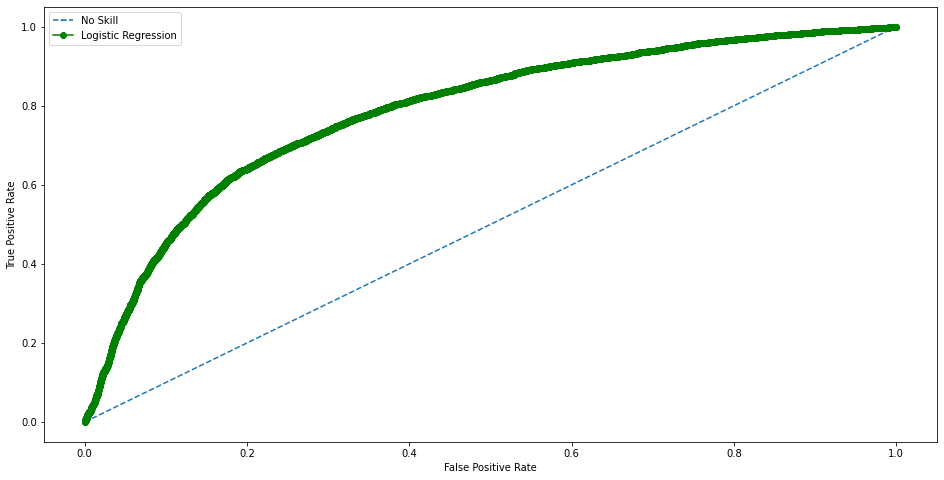

```python
# generate a no skill prediction (majority class)
no_skill_prob=[0 for _ in range(len(X_test))]

#Predict Probabilities
logis_prob=logis_best.predict_proba(X_test)
logis_prob=logis_prob[:,1]
#Calculating scores
no_skill_auc=roc_auc_score(Y_test,no_skill_prob)
logis_auc=roc_auc_score(Y_test,logis_prob)
# Printing the summarized scores
print('No Skill: ROC AUC=%.3f' % (no_skill_auc))
print('Decision Tree : ROC AUC=%.3f' % (logis_auc))
# calculate roc curves
ns_fpr, ns_tpr, _ = roc_curve(Y_test, no_skill_prob)
logis_fpr, logis_tpr, _ = roc_curve(Y_test, logis_prob)
# plot the roc curve for the model
plt.figure(figsize=(16,8))
plt.plot(ns_fpr, ns_tpr, linestyle='--', label='No Skill',marker='_')
plt.plot(logis_fpr, logis_tpr, color='g', label='Logistic Regression',marker='8')
# axis labels
plt.xlabel('False Positive Rate')
plt.ylabel('True Positive Rate')
# show the legend
plt.legend()
# show the plot
plt.show()
```

## Decision Tree

**The hyperparameters tuned are**

```python
clf=DecisionTreeClassifier()
cv=StratifiedKFold(n_splits=5,shuffle=True)
param_grid = {'criterion': ['gini', 'entropy'],
              'min_samples_split': [1,2, 10],
              'max_depth': [5, 10, 20, 25],
              'min_samples_leaf': [1, 5, 10],
               'max_leaf_nodes': [25,50]
              }
gs_dc=GridSearchCV(estimator=clf,cv=cv,scoring="recall",param_grid=param_grid,n_jobs=-1)
```

```python
gs_dc.fit(X_train,Y_train)
```

```
GridSearchCV(cv=StratifiedKFold(n_splits=5, random_state=None, shuffle=True),
             error_score=nan,
             estimator=DecisionTreeClassifier(ccp_alpha=0.0, class_weight=None,
                                              criterion='gini', max_depth=None,
                                              max_features=None,
                                              max_leaf_nodes=None,
                                              min_impurity_decrease=0.0,
                                              min_impurity_split=None,
                                              min_samples_leaf=1,
                                              min_samples_split=2,
                                              min_weight_fraction_leaf=0.0,
                                              presort='deprecated',
                                              random_state=None,
                                              splitter='best'),
             iid='deprecated', n_jobs=-1,
             param_grid={'criterion': ['gini', 'entropy'],
                         'max_depth': [5, 10, 20, 25],
                         'max_leaf_nodes': [25, 50],
                         'min_samples_leaf': [1, 5, 10],
                         'min_samples_split': [1, 2, 10]},
             pre_dispatch='2*n_jobs', refit=True, return_train_score=False,
             scoring='recall', verbose=0)
```

```python
for hp,values in gs_dc.best_params_.items():
  print(f"{hp}:{values}")
```

```
criterion:entropy
max_depth:10
max_leaf_nodes:50
min_samples_leaf:10
min_samples_split:2
```

```python
dc_best=gs_dc.best_estimator_
y_pred=dc_best.predict(X_test)
```

```python
print(f"Precision:{round (metrics.precision_score(y_pred,Y_test)*100)}%")
print(f"Recall : {round(metrics.recall_score(y_pred,Y_test)*100)}%")
print(f"Accuracy: {round (metrics.accuracy_score(y_pred,Y_test)*100)}%")
print(classification_report(y_pred,Y_test))
```

```
Precision:72.0%
Recall : 75.0%
Accuracy: 73.0%
              precision    recall  f1-score   support

           0       0.74      0.71      0.73      7634
           1       0.72      0.75      0.73      7526

    accuracy                           0.73     15160
   macro avg       0.73      0.73      0.73     15160
weighted avg       0.73      0.73      0.73     15160
```

## ROC-Curve-Decision Tree

```
No Skill: ROC AUC=0.500
Decision Tree : ROC AUC=0.789
```

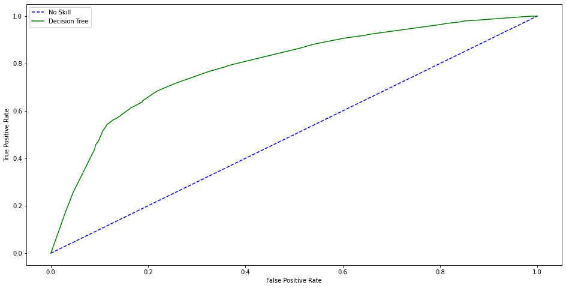

```python
# generate a no skill prediction (majority class)
noskill_prob = [0 for _ in range(len(X_test))]

# predict probabilities
dec_tree_prob = dc_best.predict_proba(X_test)
dec_tree_prob = dec_tree_prob[:, 1]
# calculating  scores
noskill_auc = roc_auc_score(Y_test,noskill_prob)
dec_tree_auc = roc_auc_score(Y_test, dec_tree_prob)
# Printing the summarized scores
print('No Skill: ROC AUC=%.3f' % (noskill_auc))
print('Decision Tree : ROC AUC=%.3f' % (dec_tree_auc))
# calculate roc curves
ns_fpr, ns_tpr, _ = roc_curve(Y_test, noskill_prob)
dec_tree_fpr, dec_tree_tpr, _ = roc_curve(Y_test, dec_tree_prob)
# plot the roc curve for the model
plt.figure(figsize=(16,8))
plt.plot(ns_fpr, ns_tpr, linestyle='--',color='b',label='No Skill')
plt.plot(dec_tree_fpr, dec_tree_tpr, color='g', label='Decision Tree')
# axis labels
plt.xlabel('False Positive Rate')
plt.ylabel('True Positive Rate')
# show the legend
plt.legend()
# show the plot
plt.show()
```

## ANN-0

```python
from keras.models import Sequential
from keras.layers import Dense
from keras.layers import Dropout
from keras.layers import Activation
import pandas
from keras.wrappers.scikit_learn import KerasClassifier
from sklearn.model_selection import cross_val_score
from sklearn.model_selection import StratifiedKFold
from sklearn.preprocessing import StandardScaler
from sklearn.pipeline import Pipeline
from keras.layers import LeakyReLU
from keras.callbacks import EarlyStopping,ModelCheckpoint
```

```python
model_ann0=Sequential()
```

```python
X=dumdf.drop('Disease',axis=1)
Y=df['Disease']
X_train, X_test, Y_train, Y_test = train_test_split(X, Y, test_size = 0.30, random_state=33)
```

```python
X_train=X_train.values
Y_train=Y_train.values
X_test=X_test.values
Y_test=Y_test.values
```

```python
scalar=StandardScaler()
X_train=scalar.fit_transform(X_train)
X_test=scalar.fit_transform(X_test)
```

```python
print(X_train.shape,Y_train.shape)
```

```
(32157, 17) (32157,)
```

Making a Sequential Model

```python
model_ann0.add(Dense(1,activation='sigmoid',kernel_initializer='uniform'))
model_ann0.compile(optimizer='rmsprop',loss='binary_crossentropy',metrics=['accuracy'])
```

```python
es=[EarlyStopping(monitor='val_loss',patience=2),ModelCheckpoint(monitor='val_loss',filepath='best_model.h5',save_best_only=True)]
history=model_ann0.fit(X_train,Y_train,epochs=100,batch_size=118,verbose=0)
```

```python
y_pred=model_ann0.predict(X_test)
pred=list()
for i in range(len(y_pred)):
  pred.append(y_pred[i])
#Argmax returns the index with the highest value
test=list()
for i in range(len(Y_test)):
  test.append(Y_test[i])
```

```python
from sklearn.metrics import accuracy_score
pred=list(np.around(np.array(pred),0))
print(f"Precision:{round (metrics.precision_score(pred,Y_test)*100)}%")
print(f"Recall : {round(metrics.recall_score(pred,Y_test)*100)}%")
print(f"Accuracy: {round (metrics.accuracy_score(pred,Y_test)*100)}%")
print(classification_report(pred,Y_test))
```

```
Precision:70.0%
Recall : 76.0%
Accuracy: 73.0%
              precision    recall  f1-score   support

         0.0       0.76      0.70      0.73      7184
         1.0       0.70      0.76      0.73      6598

    accuracy                           0.73     13782
   macro avg       0.73      0.73      0.73     13782
weighted avg       0.73      0.73      0.73     13782
```

```python
train_ann0=model_ann0.fit(X_train,Y_train,batch_size=118,epochs=100,validation_data=(X_test,Y_test),verbose=0)
#Usually, the dataset is very big and we cannot fit complete data at once so we use batch size
```

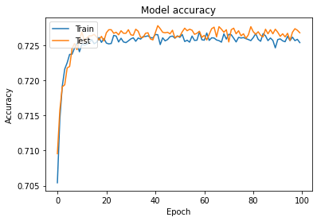

```python
import matplotlib.pyplot as plt
plt.plot(train_ann0.history['accuracy'])
plt.plot(train_ann0.history['val_accuracy'])
plt.title('Model accuracy')
plt.ylabel('Accuracy')
plt.xlabel('Epoch')
plt.legend(['Train', 'Test'], loc='upper left')
fig=plt.figure(figsize=(20,8))
```

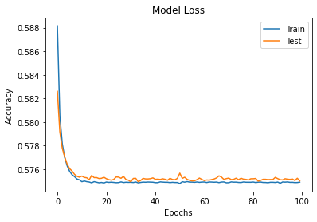

```python
plt.plot(train_ann0.history['loss'])
plt.plot(train_ann0.history['val_loss'])
plt.title('Model Loss')
plt.xlabel('Epochs')
plt.ylabel('Accuracy')
plt.legend(['Train', 'Test'])

plt.show()
```

## ANN-0(ROC-CURVE)

```
No Skill: ROC AUC=0.500
ANN-0 No Hidden Layer : ROC AUC=0.789
```

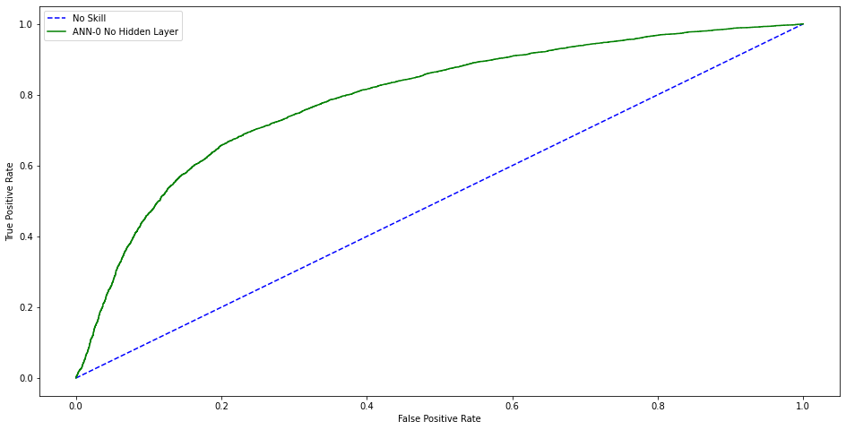

```python
# generate a no skill prediction (majority class)
noskill_prob = [0 for _ in range(len(X_test))]

# predict probabilities
ann0_prob = model.predict_proba(X_test)
ann0_prob = ann0_prob[:]
# calculating  scores
noskill_auc = roc_auc_score(Y_test,noskill_prob)
ann0_auc = roc_auc_score(Y_test, ann0_prob)
# Printing the summarized scores
print('No Skill: ROC AUC=%.3f' % (noskill_auc))
print('ANN-0 No Hidden Layer : ROC AUC=%.3f' % (ann0_auc))
# calculate roc curves
ns_fpr, ns_tpr, _ = roc_curve(Y_test, noskill_prob)
ann0_fpr, ann0_tpr, _ = roc_curve(Y_test, ann0_prob)
# plot the roc curve for the model
plt.figure(figsize=(16,8))
plt.plot(ns_fpr, ns_tpr, linestyle='--',color='b',label='No Skill')
plt.plot(ann0_fpr, ann0_tpr, color='g', label='ANN-0 No Hidden Layer')
# axis labels
plt.xlabel('False Positive Rate')
plt.ylabel('True Positive Rate')
# show the legend
plt.legend()
# show the plot
plt.show()
```

## ANN-1

```python
from keras.models import Sequential
from keras.layers import Dense
from keras.layers import Dropout
from keras.layers import Activation
import pandas
from keras.wrappers.scikit_learn import KerasClassifier
from sklearn.model_selection import cross_val_score
from sklearn.model_selection import StratifiedKFold
from sklearn.preprocessing import StandardScaler
from sklearn.pipeline import Pipeline
from keras.layers import LeakyReLU
from keras.callbacks import EarlyStopping
```

The Sequential model is a linear stack of layers.

You can create a Sequential model by passing a list of layer instances to the constructor:

```python
model=Sequential()
```

A general problem with both the sigmoid and tanh functions is that they saturate. This means that large values snap to 1.0 and small values snap to -1 or 0 for tanh and sigmoid respectively. Further, the functions are only really sensitive to changes around their mid-point of their input, such as 0.5 for sigmoid and 0.0 for tanh.

The limited sensitivity and saturation of the function happen regardless of whether the summed activation from the node provided as input contains useful information or not. Once saturated, it becomes challenging for the learning algorithm to continue to adapt the weights to improve the performance of the model.

*The rectified linear activation function(RELU) overcomes the vanishing gradient problem, allowing models to learn faster and perform better.*

```python
def create_baseline(optimizer):
  model.add(Dense(10,activation='relu',kernel_initializer='uniform',input_dim=17))
  model.add(Dense(1,activation='sigmoid',kernel_initializer='uniform'))
  #Compile Model
  model.compile(loss='binary_crossentropy', optimizer='rmsprop', metrics=['accuracy'])
  return model
```

```python
X=dumdf.drop('Disease',axis=1)
Y=df['Disease']
X_train, X_test, Y_train, Y_test = train_test_split(X, Y, test_size = 0.30, random_state=33)
```

```python
X_train=X_train.values
Y_train=Y_train.values
X_test=X_test.values
Y_test=Y_test.values
```

```python
scalar=StandardScaler()
X_train=scalar.fit_transform(X_train)
X_test=scalar.fit_transform(X_test)
```

```python
print(X_train.shape,Y_train.shape)
```

```
(32157, 17) (32157,)
```

I have used KerasClassifier wrapper. This class takes a function that creates and returns our neural network model. It also takes arguments that it will pass along to the call to fit() such as the number of epochs and the batch size.-The number of epochs is a hyperparameter that defines the number times that the learning algorithm will work through the entire training dataset.

- One epoch means that each sample in the training dataset has had an opportunity to update the internal model parameters. An epoch is comprised of one or more batches.
- A batch size of 118 means that 118 samples from the training dataset will be used to estimate the error gradient before the model weights are updated. 10 training epoch means that the learning algorithm has made ten passes through the training dataset, where examples were separated into randomly selected “batch size” groups.

```python
# evaluate baseline model with standardized dataset
kfold=StratifiedKFold(n_splits=10,shuffle=True)
estimator=KerasClassifier(build_fn=create_baseline,verbose=0)
params={'epochs':(10,20),
        'batch_size':(118,120,100),
        'optimizer':('rmsprop','adam')
        }
gs=GridSearchCV(estimator=estimator,cv=kfold,n_jobs=-1,param_grid=params,scoring='precision')
gs.fit(X_train,Y_train)
```

```
GridSearchCV(cv=StratifiedKFold(n_splits=10, random_state=None, shuffle=True),
             error_score=nan,
             estimator=<keras.wrappers.scikit_learn.KerasClassifier object at 0x7f2841dda0f0>,
             iid='deprecated', n_jobs=-1,
             param_grid={'batch_size': (118, 120, 100), 'epochs': (10, 20),
                         'optimizer': ('rmsprop', 'adam')},
             pre_dispatch='2*n_jobs', refit=True, return_train_score=False,
             scoring='precision', verbose=0)
```

```python
for hps,values in gs.best_params_.items():
  print(hps,values)
gs_best_ann1=gs.best_estimator_
```

```
batch_size 100
epochs 20
optimizer rmsprop
```

```python
y_pred=gs_best_ann1.predict(X_test)
print(f"Precision:{round (metrics.precision_score(y_pred,Y_test)*100)}%")
print(f"Recall : {round(metrics.recall_score(y_pred,Y_test)*100)}%")
print(f"Accuracy: {round (metrics.accuracy_score(y_pred,Y_test)*100)}%")
print(classification_report(y_pred,Y_test))
```

```
Precision:73.0%
Recall : 74.0%
Accuracy: 73.0%
              precision    recall  f1-score   support

           0       0.73      0.71      0.72      6819
           1       0.73      0.74      0.73      6963

    accuracy                           0.73     13782
   macro avg       0.73      0.73      0.73     13782
weighted avg       0.73      0.73      0.73     13782
```

## ANN-1 ROC-Curve

```
No Skill: ROC AUC=0.500
ANN-1 Hidden Layer : ROC AUC=0.793
```

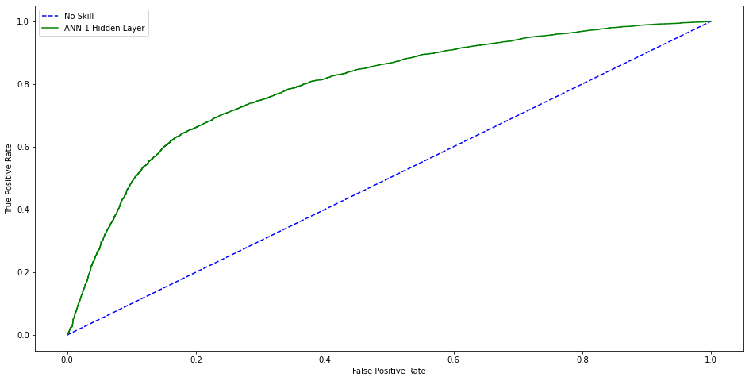

```python
# generate a no skill prediction (majority class)
noskill_prob = [0 for _ in range(len(X_test))]

# predict probabilities
ann1_prob = gs.predict_proba(X_test)
ann1_prob = ann1_prob[:, 1]
# calculating  scores
noskill_auc = roc_auc_score(Y_test,noskill_prob)
ann1_auc = roc_auc_score(Y_test, ann1_prob)
# Printing the summarized scores
print('No Skill: ROC AUC=%.3f' % (noskill_auc))
print('ANN-1 Hidden Layer : ROC AUC=%.3f' % (ann1_auc))
# calculate roc curves
ns_fpr, ns_tpr, _ = roc_curve(Y_test, noskill_prob)
ann1_fpr, ann1_tpr, _ = roc_curve(Y_test, ann1_prob)
# plot the roc curve for the model
plt.figure(figsize=(16,8))
plt.plot(ns_fpr, ns_tpr, linestyle='--',color='b',label='No Skill')
plt.plot(ann1_fpr, ann1_tpr, color='g', label='ANN-1 Hidden Layer')
# axis labels
plt.xlabel('False Positive Rate')
plt.ylabel('True Positive Rate')
# show the legend
plt.legend()
# show the plot
plt.show()
```

## ANN-2

```python
from keras.models import Sequential
from keras.layers import Dense
from keras.layers import Dropout
from keras.layers import Activation
import pandas
from keras.wrappers.scikit_learn import KerasClassifier
from sklearn.model_selection import cross_val_score
from sklearn.model_selection import StratifiedKFold
from sklearn.preprocessing import StandardScaler
from sklearn.pipeline import Pipeline
from keras.layers import LeakyReLU
from keras.callbacks import EarlyStopping
```

```python
model=Sequential()
```

**Applying Dropout of 0.1**

```python
def create_baseline(optimizer):
  #First Hidden Layer
  model.add(Dense(10,activation='relu',kernel_initializer='uniform',input_dim=17))
  model.add(Dropout(0.1))
  model.add(Dense(10,activation='relu',kernel_initializer='uniform',input_dim=17))
  model.add(Dense(1,activation='sigmoid',kernel_initializer='uniform'))
  #Compile Model
  model.compile(loss='binary_crossentropy', optimizer='adam', metrics=['accuracy'])
  return model
```

```python
X=dumdf.drop('Disease',axis=1)
Y=df['Disease']
X_train, X_test, Y_train, Y_test = train_test_split(X, Y, test_size = 0.30, random_state=33)
```

```python
X_train=X_train.values
Y_train=Y_train.values
X_test=X_test.values
Y_test=Y_test.values
```

```python
scalar=StandardScaler()
X_train=scalar.fit_transform(X_train)
X_test=scalar.fit_transform(X_test)
```

Adam can be looked at as a combination of RMSprop and Stochastic Gradient Descent with momentum. It uses the squared gradients to scale the learning rate like RMSprop and it takes advantage of momentum by using moving average of the gradient instead of gradient itself like SGD with momentum.

**Adam Optimizer**

Adam is an adaptive learning rate method, which means, it computes individual learning rates for different parameters. Its name is derived from adaptive moment estimation, and the reason it’s called that is because Adam uses estimations of first and second moments of gradient to adapt the learning rate for each weight of the neural network

**RMS Prop Optimizer**

Gradients of very complex functions like neural networks have a tendency to either vanish or explode as the energy is propagated through the function. And the effect has a cumulative nature — the more complex the function is, the worse the problem becomes. Rmsprop is a very clever way to deal with the problem. It uses a moving average of squared gradients to normalize the gradient itself. That has an effect of balancing the step size — decrease the step for large gradient to avoid exploding, and increase the step for small gradient to avoid vanishing.

```python
# evaluate baseline model with standardized dataset
kfold=StratifiedKFold(n_splits=10,shuffle=True)
estimator=KerasClassifier(build_fn=create_baseline,batch_size=10,epochs=100,verbose=0)
params={'epochs':(15,20,30),
        'batch_size':(110,120,130),
        'optimizer':['adam','rmsprop']
        }
gs=GridSearchCV(estimator=estimator,cv=kfold,n_jobs=-1,scoring='precision',param_grid=params)
gs.fit(X_train,Y_train)
```

```
GridSearchCV(cv=StratifiedKFold(n_splits=10, random_state=None, shuffle=True),
             error_score=nan,
             estimator=<keras.wrappers.scikit_learn.KerasClassifier object at 0x7f2841e466a0>,
             iid='deprecated', n_jobs=-1,
             param_grid={'batch_size': (110, 120, 130), 'epochs': (15, 20, 30),
                         'optimizer': ['adam', 'rmsprop']},
             pre_dispatch='2*n_jobs', refit=True, return_train_score=False,
             scoring='precision', verbose=0)
```

```python
for hps,values in gs.best_params_.items():
  print(hps,values)
gs_best_ann2=gs.best_estimator_
```

```
batch_size 110
epochs 30
optimizer rmsprop
```

```python
y_pred=gs_best.predict(X_test)
print(f"Precision:{round (metrics.precision_score(y_pred,Y_test)*100)}%")
print(f"Recall : {round(metrics.recall_score(y_pred,Y_test)*100)}%")
print(f"Accuracy: {round (metrics.accuracy_score(y_pred,Y_test)*100)}%")
print(classification_report(y_pred,Y_test))
```

```
Precision:72.0%
Recall : 75.0%
Accuracy: 73.0%
              precision    recall  f1-score   support

           0       0.75      0.71      0.73      6974
           1       0.72      0.75      0.74      6808

    accuracy                           0.73     13782
   macro avg       0.73      0.73      0.73     13782
weighted avg       0.73      0.73      0.73     13782
```

## ANN2-ROC

```
No Skill: ROC AUC=0.500
ANN-1 Hidden Layer : ROC AUC=0.796
```

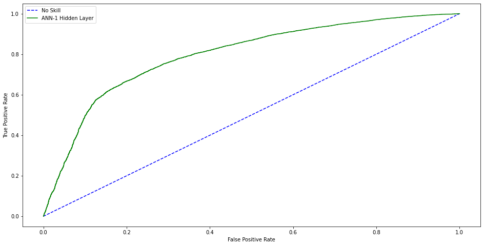

```python
# generate a no skill prediction (majority class)
noskill_prob = [0 for _ in range(len(X_test))]

# predict probabilities
ann2_prob = gs.predict_proba(X_test)
ann2_prob = ann2_prob[:, 1]
# calculating  scores
noskill_auc = roc_auc_score(Y_test,noskill_prob)
ann2_auc = roc_auc_score(Y_test, ann2_prob)
# Printing the summarized scores
print('No Skill: ROC AUC=%.3f' % (noskill_auc))
print('ANN-1 Hidden Layer : ROC AUC=%.3f' % (ann2_auc))
# calculate roc curves
ns_fpr, ns_tpr, _ = roc_curve(Y_test, noskill_prob)
ann2_fpr, ann2_tpr, _ = roc_curve(Y_test, ann2_prob)
# plot the roc curve for the model
plt.figure(figsize=(16,8))
plt.plot(ns_fpr, ns_tpr, linestyle='--',color='b',label='No Skill')
plt.plot(ann2_fpr, ann2_tpr, color='g', label='ANN-1 Hidden Layer')
# axis labels
plt.xlabel('False Positive Rate')
plt.ylabel('True Positive Rate')
# show the legend
plt.legend()
# show the plot
plt.show()
```

## Difference Between SVM,Logistic-Regression and ANN0

Performance is a linear combination of all independent features  
A Linear hyerplane is drawn to differentiate between positive and negative target variables Both ANN-0 when used with a sigmoid activation function and logistic regression use binary cross entropy loss to diffrentiate between the target variables

However in ANN-0 the weights are updated as back-propogation is used. Back-propogation is an iterative method. We start with some set of values for our model parameters (weights and biases), and improve them slowly.

Partial computations of the gradient from one layer are reused in the computation of the gradient for the previous layer. This backwards flow of the error information allows for efficient computation of the gradient at each layer thus reducing the cost

This is the reason we get lower costs and thus higher accuracies for ANN-0 than for logistic regression

## Feature Importance

Feature selection is a process where you automatically select those features in your data that contribute most to the prediction variable or output in which you are interested. Three benefits of performing feature selection before modeling your data are:

- Reduces Overfitting: Less redundant data means less opportunity to make decisions based on noise.
- Improves Accuracy: Less misleading data means modeling accuracy improves.
- Reduces Training Time: Less data means that algorithms train faster.

```python
from sklearn.feature_selection import SelectFromModel
```

```python
X=dumdf.drop('Disease',axis=1)
Y=df['Disease']
X_train, X_test, Y_train, Y_test = train_test_split(X, Y, test_size = 0.30, random_state=33)
```

Feature Selection for Random Forest

```python
sel_rf=SelectFromModel(estimator=RandomForestClassifier(n_estimators=100,max_depth=15,criterion='gini',min_samples_leaf=20,max_leaf_nodes=15,max_features='log2',class_weight='balanced'))
sel_rf.fit(X_train,Y_train)
selected_feat_rf= X_Train.columns[(sel_rf.get_support())]
```

```python
importances = sel_rf.estimator_.feature_importances_
features = dumdf.drop('Disease',axis=1).columns
```

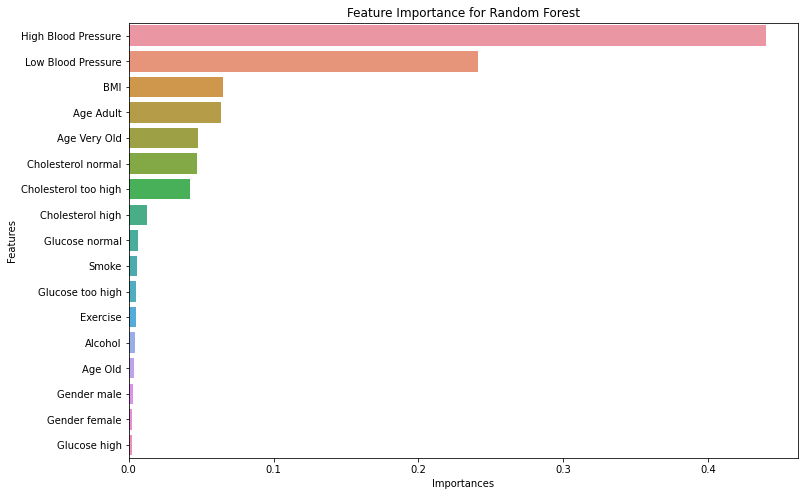

```python
imp_df = pd.DataFrame(list(zip(importances,features)),columns = ['Importances','Features'])
imp_df.sort_values(by = 'Importances',ascending = False,inplace=True)
fig=plt.figure(figsize=(12,8))
fig.show
sns.barplot(x = 'Importances',y = 'Features',data = imp_df).set_title("Feature Importance for Random Forest")
```

Feature Selection for Gradient Boosting

```python
from sklearn.ensemble import GradientBoostingClassifier
sel_gb=SelectFromModel(estimator=GradientBoostingClassifier(n_estimators=100,learning_rate=0.1,max_depth=5,max_features='log2',min_samples_leaf=1))
sel_gb.fit(X_train,Y_train)
importances=sel_gb.estimator_.feature_importances_
features=dumdf.drop('Disease',axis=1).columns
```

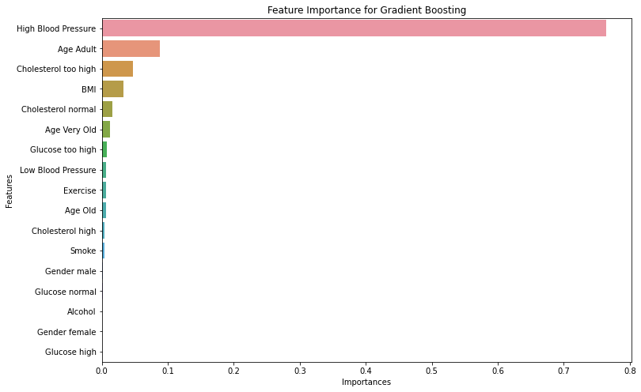

```python
imp_df=pd.DataFrame(list(zip(importances,features)),columns=['Importances','Features'])
imp_df.sort_values(by = 'Importances',ascending = False,inplace=True)
fig=plt.figure(figsize=(12,8))
fig.show
sns.barplot(x = 'Importances',y = 'Features',data = imp_df).set_title("Feature Importance for Gradient Boosting")
```

Feature Selection for Decision Tree

```python
sel_dt=SelectFromModel(estimator=DecisionTreeClassifier(criterion='entropy',max_depth=10,max_leaf_nodes=50,min_samples_leaf=5,min_samples_split=2))
sel_dt.fit(X_train,Y_train)
importances=sel_dt.estimator_.feature_importances_
features=dumdf.drop('Disease',axis=1).columns
```

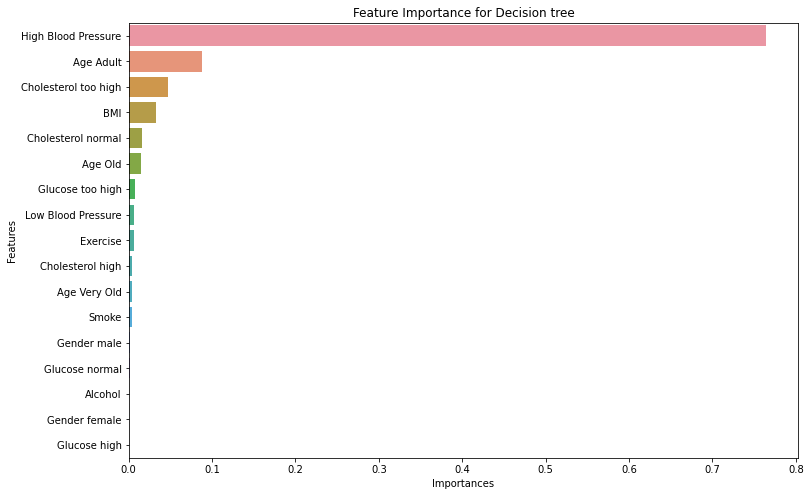

```python
imp_df=pd.DataFrame(list(zip(importances,features)),columns=['Importances','Features'])
imp_df.sort_values(by = 'Importances',ascending = False,inplace=True)
fig=plt.figure(figsize=(12,8))
fig.show
sns.barplot(x = 'Importances',y = 'Features',data = imp_df).set_title("Feature Importance for Decision tree")
```

Feature Selection for Logistic Regression

```python
from sklearn.feature_selection import RFE
sel_logistic=LogisticRegression(penalty='l2',C=0.001,class_weight='balanced',multi_class='ovr',solver='newton-cg')
rfe = RFE(sel_logistic, 3)
fit = rfe.fit(X_Train, Y_Train)
print("Num Features: %d" % fit.n_features_)
print("Selected Features: %s" % fit.support_)
print("Feature Ranking: %s" % fit.ranking_)
```

```
Num Features: 3
Selected Features: [False False False False False False  True False False False False False
  True  True False False False]
Feature Ranking: [ 6 11  4  5  3  7  1  9  2 10 12  8  1  1 14 15 13]
```

## Combination and Comparison of Multiple Machine Learning Algorithms

1.Random Forest

```python
from sklearn.ensemble import RandomForestClassifier
X=dumdf.drop('Disease',axis=1)
Y=dumdf['Disease']
```

```python
normalizedf=preprocessing.MinMaxScaler()
normalizedf=normalizedf.fit_transform(dumdf)
normalizedf=pd.DataFrame(normalizedf,columns=dumdf.columns,index=dumdf.index)
X_Train,X_Test,Y_Train,Y_Test=train_test_split(X,Y,test_size=0.3,random_state=38)
```

```python
cv = StratifiedKFold(n_splits=10,shuffle=True)
rm= RandomForestClassifier()
params={'max_depth':[15],
        'criterion':['gini'],
        'min_samples_leaf':[25],
        'max_leaf_nodes':[15],
        'max_features':['log2'],
        'class_weight':['balanced'],
  }
grid_search_rf=GridSearchCV(estimator=rm,param_grid=params,cv=cv,scoring="accuracy",n_jobs=-1)
grid_search_rf.fit(X_Train,Y_Train)
```

```
GridSearchCV(cv=StratifiedKFold(n_splits=10, random_state=None, shuffle=True),
             error_score=nan,
             estimator=RandomForestClassifier(bootstrap=True, ccp_alpha=0.0,
                                              class_weight=None,
                                              criterion='gini', max_depth=None,
                                              max_features='auto',
                                              max_leaf_nodes=None,
                                              max_samples=None,
                                              min_impurity_decrease=0.0,
                                              min_impurity_split=None,
                                              min_samples_leaf=1,
                                              min_samples_split=2,...
                                              n_estimators=100, n_jobs=None,
                                              oob_score=False,
                                              random_state=None, verbose=0,
                                              warm_start=False),
             iid='deprecated', n_jobs=-1,
             param_grid={'class_weight': ['balanced'], 'criterion': ['gini'],
                         'max_depth': [15], 'max_features': ['log2'],
                         'max_leaf_nodes': [15], 'min_samples_leaf': [25]},
             pre_dispatch='2*n_jobs', refit=True, return_train_score=False,
             scoring='accuracy', verbose=0)
```

```python
print(f"Grid Search Random forest:{grid_search_rf.best_score_}")
for hyperparam,value in grid_search_rf.best_params_.items():
  print(f"{hyperparam,value}")
rf_best=grid_search_rf.best_estimator_
rf_best.fit(X_Train,Y_Train)
```

```
Grid Search Random forest:0.7253788309618316
('class_weight', 'balanced')
('criterion', 'gini')
('max_depth', 15)
('max_features', 'log2')
('max_leaf_nodes', 15)
('min_samples_leaf', 25)
```

```
RandomForestClassifier(bootstrap=True, ccp_alpha=0.0, class_weight='balanced',
                       criterion='gini', max_depth=15, max_features='log2',
                       max_leaf_nodes=15, max_samples=None,
                       min_impurity_decrease=0.0, min_impurity_split=None,
                       min_samples_leaf=25, min_samples_split=2,
                       min_weight_fraction_leaf=0.0, n_estimators=100,
                       n_jobs=None, oob_score=False, random_state=None,
                       verbose=0, warm_start=False)
```

```python
y_pred=rf_best.predict(X_Test)
print(f"Precision:{round (metrics.precision_score(y_pred,Y_Test)*100)}%")
print(f"Recall : {round(metrics.recall_score(y_pred,Y_Test)*100)}%")
print(f"Accuracy: {round (metrics.accuracy_score(y_pred,Y_Test)*100)}%")
print(classification_report(y_pred,Y_Test))
rf_prob = rf_best.predict_proba(X_Test)
rf_prob = rf_prob[:, 1]
rf_auc = roc_auc_score(Y_Test,rf_prob)
print('Random forest: ROC AUC=%.3f' % (rf_auc))
```

```
Precision:70.0%
Recall : 75.0%
Accuracy: 73.0%
              precision    recall  f1-score   support

           0       0.76      0.71      0.73      7195
           1       0.70      0.75      0.73      6587

    accuracy                           0.73     13782
   macro avg       0.73      0.73      0.73     13782
weighted avg       0.73      0.73      0.73     13782

Random forest: ROC AUC=0.796
```

2.Gradient Boosting

```python
from sklearn.ensemble import RandomForestClassifier
X=dumdf.drop('Disease',axis=1)
Y=dumdf['Disease']
```

```python
normalizedf=preprocessing.MinMaxScaler()
normalizedf=normalizedf.fit_transform(dumdf)
normalizedf=pd.DataFrame(normalizedf,columns=dumdf.columns,index=dumdf.index)
```

```python
X=normalizedf.drop('Disease',axis=1)
Y=dumdf['Disease']
X_Train,X_Test,Y_Train,Y_Test=train_test_split(X,Y,test_size=0.3,random_state=42)
```

```python
cv=StratifiedKFold(n_splits=5,shuffle=True,random_state=True)
params={'max_depth':[5],
        'learning_rate' : [ 0.1],
        'min_samples_leaf':[1],
        'max_features':['log2']
  }
gbm=GradientBoostingClassifier()
grid_search_gb= GridSearchCV(estimator=gbm, param_grid=params,scoring="accuracy",n_jobs=-1,cv=cv,verbose=1)
grid_search_gb.fit(X_Train,Y_Train)
```

```
Fitting 5 folds for each of 1 candidates, totalling 5 fits
```

```
[Parallel(n_jobs=-1)]: Using backend LokyBackend with 2 concurrent workers.
[Parallel(n_jobs=-1)]: Done   5 out of   5 | elapsed:    7.3s finished
```

```
GridSearchCV(cv=StratifiedKFold(n_splits=5, random_state=True, shuffle=True),
             error_score=nan,
             estimator=GradientBoostingClassifier(ccp_alpha=0.0,
                                                  criterion='friedman_mse',
                                                  init=None, learning_rate=0.1,
                                                  loss='deviance', max_depth=3,
                                                  max_features=None,
                                                  max_leaf_nodes=None,
                                                  min_impurity_decrease=0.0,
                                                  min_impurity_split=None,
                                                  min_samples_leaf=1,
                                                  min_samples_split=2,...
                                                  n_iter_no_change=None,
                                                  presort='deprecated',
                                                  random_state=None,
                                                  subsample=1.0, tol=0.0001,
                                                  validation_fraction=0.1,
                                                  verbose=0, warm_start=False),
             iid='deprecated', n_jobs=-1,
             param_grid={'learning_rate': [0.1], 'max_depth': [5],
                         'max_features': ['log2'], 'min_samples_leaf': [1]},
             pre_dispatch='2*n_jobs', refit=True, return_train_score=False,
             scoring='accuracy', verbose=1)
```

```python
gb_best=grid_search_gb.best_estimator_
gb_best.fit(X_Train,Y_Train)
y_pred=gb_best.predict(X_Test)
print(f"Precision:{round (metrics.precision_score(y_pred,Y_Test)*100)}%")
print(f"Recall : {round(metrics.recall_score(y_pred,Y_Test)*100)}%")
print(f"Accuracy: {round (metrics.accuracy_score(y_pred,Y_Test)*100)}%")
print(classification_report(y_pred,Y_Test))

gb_prob = gb_best.predict_proba(X_Test)
gb_prob = gb_prob[:, 1]
gb_auc = roc_auc_score(Y_Test,gb_prob)
print('Gradient Boosting: ROC AUC=%.3f' % (gb_auc))
```

```
Precision:69.0%
Recall : 76.0%
Accuracy: 73.0%
              precision    recall  f1-score   support

           0       0.77      0.70      0.73      7312
           1       0.69      0.76      0.73      6470

    accuracy                           0.73     13782
   macro avg       0.73      0.73      0.73     13782
weighted avg       0.73      0.73      0.73     13782

Gradient Boosting: ROC AUC=0.794
```

3.Linear SVM

```python
from sklearn.ensemble import RandomForestClassifier
normalizedf=preprocessing.StandardScaler()
normalizedf=normalizedf.fit_transform(dumdf)
normalizedf=pd.DataFrame(normalizedf,columns=dumdf.columns,index=dumdf.index)
X=normalizedf.drop('Disease',axis=1)
Y=dumdf['Disease']
X_Train,X_Test,Y_Train,Y_Test=train_test_split(X,Y,test_size=0.3,random_state=38)
```

```python
svclassifier=SVC(kernel='linear')
bs=model_selection.ShuffleSplit(test_size=0.3,random_state=42)
param_grid = {'C':[1]}
grid_search=GridSearchCV(estimator=svclassifier,param_grid=param_grid,scoring="accuracy",cv=bs,n_jobs=-1)
grid_search.fit(X_Train,Y_Train)
```

```
GridSearchCV(cv=ShuffleSplit(n_splits=10, random_state=42, test_size=0.3, train_size=None),
             error_score=nan,
             estimator=SVC(C=1.0, break_ties=False, cache_size=200,
                           class_weight=None, coef0=0.0,
                           decision_function_shape='ovr', degree=3,
                           gamma='scale', kernel='linear', max_iter=-1,
                           probability=False, random_state=None, shrinking=True,
                           tol=0.001, verbose=False),
             iid='deprecated', n_jobs=-1, param_grid={'C': [1]},
             pre_dispatch='2*n_jobs', refit=True, return_train_score=False,
             scoring='accuracy', verbose=0)
```

```python
linearSVC=grid_search.best_estimator_
linearSVC.fit(X_Train,Y_Train)
y_pred=linearSVC.predict(X_Test)
print(f"Precision:{round (metrics.precision_score(y_pred,Y_Test)*100)}%")
print(f"Recall : {round(metrics.recall_score(y_pred,Y_Test)*100)}%")
print(f"Accuracy: {round (metrics.accuracy_score(y_pred,Y_Test)*100)}%")
print(classification_report(y_pred,Y_Test))

svm_prob=svm.SVC(kernel='linear',probability=True,C=1).fit(X_Train,Y_Train)
svm_prob=svm_prob.predict_proba(X_Test)
svm_prob=svm_prob[:,1]
svm_auc=roc_auc_score(Y_Test,svm_prob)
print('SVM: ROC AUC=%.3f' % (svm_auc))
```

```
Precision:67.0%
Recall : 77.0%
Accuracy: 73.0%
              precision    recall  f1-score   support

           0       0.80      0.70      0.74      7712
           1       0.67      0.77      0.72      6070

    accuracy                           0.73     13782
   macro avg       0.73      0.73      0.73     13782
weighted avg       0.74      0.73      0.73     13782

SVM: ROC AUC=0.791
```

4.SVM-Non-Linear

```python
from sklearn.ensemble import RandomForestClassifier
normalizedf=preprocessing.StandardScaler()
normalizedf=normalizedf.fit_transform(dumdf)
normalizedf=pd.DataFrame(normalizedf,columns=dumdf.columns,index=dumdf.index)
X=normalizedf.drop('Disease',axis=1)
Y=dumdf['Disease']
X_Train,X_Test,Y_Train,Y_Test=train_test_split(X,Y,test_size=0.3)
```

```python
svclassifier=SVC(kernel='rbf',gamma='auto',class_weight='balanced',random_state=38)
param_grid = {'C': [10]  ,
              'gamma': [0.1],
              'kernel': ['rbf']}
grid_search=GridSearchCV(estimator=svclassifier,param_grid=param_grid,scoring="accuracy",n_jobs=-1)
grid_search.fit(X_Train,Y_Train)
```

```
GridSearchCV(cv=None, error_score=nan,
             estimator=SVC(C=1.0, break_ties=False, cache_size=200,
                           class_weight='balanced', coef0=0.0,
                           decision_function_shape='ovr', degree=3,
                           gamma='auto', kernel='rbf', max_iter=-1,
                           probability=False, random_state=38, shrinking=True,
                           tol=0.001, verbose=False),
             iid='deprecated', n_jobs=-1,
             param_grid={'C': [10], 'gamma': [0.1], 'kernel': ['rbf']},
             pre_dispatch='2*n_jobs', refit=True, return_train_score=False,
             scoring='accuracy', verbose=0)
```

```python
rbf_svm_best=grid_search.best_estimator_
rbf_svm_best.fit(X_Train,Y_Train)
y_pred=rbf_svm_best.predict(X_Test)
print(f"Precision:{round (metrics.precision_score(y_pred,Y_Test)*100)}%")
print(f"Recall : {round(metrics.recall_score(y_pred,Y_Test)*100)}%")
print(f"Accuracy: {round (metrics.accuracy_score(y_pred,Y_Test)*100)}%")
print(classification_report(y_pred,Y_Test))

svm_prob=svm.SVC(kernel='rbf',probability=True,C=10,gamma=0.1).fit(X_Train,Y_Train)
svm_prob=svm_prob.predict_proba(X_Test)
svm_prob=svm_prob[:,1]
svm_auc=roc_auc_score(Y_Test,svm_prob)

print('Non Linear SVM: ROC AUC=%.3f' % (svm_auc))
```

```
Precision:69.0%
Recall : 76.0%
Accuracy: 73.0%
              precision    recall  f1-score   support

           0       0.77      0.70      0.73      7352
           1       0.69      0.76      0.72      6430

    accuracy                           0.73     13782
   macro avg       0.73      0.73      0.73     13782
weighted avg       0.73      0.73      0.73     13782

Non Linear SVM: ROC AUC=0.778
```

5.Naive Bayes-Multinomial

```python
from sklearn.naive_bayes import GaussianNB, BernoulliNB, MultinomialNB
X=dumdf.drop('Disease',axis=1)
Y=dumdf['Disease']
X_Train,X_Test,Y_Train,Y_Test=train_test_split(X,Y,test_size=0.30)
```

```python
nb=MultinomialNB(fit_prior=True)
params={'alpha':(0.1,0.05,1,5)}
grid_search_nb_m=GridSearchCV(estimator=nb,cv=5,param_grid=params,scoring="recall")
grid_search_nb_m.fit(X_Train,Y_Train)
```

```
GridSearchCV(cv=5, error_score=nan,
             estimator=MultinomialNB(alpha=1.0, class_prior=None,
                                     fit_prior=True),
             iid='deprecated', n_jobs=None,
             param_grid={'alpha': (0.1, 0.05, 1, 5)}, pre_dispatch='2*n_jobs',
             refit=True, return_train_score=False, scoring='recall', verbose=0)
```

```python
multinomial_nb_best.fit(X_Test,Y_Test)
y_pred=multinomial_nb_best.predict(X_Test)
print(f"Precision:{round (metrics.precision_score(y_pred,Y_Test)*100)}%")
print(f"Recall : {round(metrics.recall_score(y_pred,Y_Test)*100)}%")
print(f"Accuracy: {round (metrics.accuracy_score(y_pred,Y_Test)*100)}%")
print(classification_report(y_pred,Y_Test))
nb_prob = multinomial_nb_best.predict_proba(X_Test)
nb_prob = nb_prob[:, 1]
nb_auc = roc_auc_score(Y_Test, nb_prob)
print('Multiinomial Naive Bayes: ROC AUC=%.3f' % (nb_auc))
```

```
Precision:63.0%
Recall : 68.0%
Accuracy: 66.0%
              precision    recall  f1-score   support

           0       0.69      0.64      0.66      7254
           1       0.63      0.68      0.65      6528

    accuracy                           0.66     13782
   macro avg       0.66      0.66      0.66     13782
weighted avg       0.66      0.66      0.66     13782

Multiinomial Naive Bayes: ROC AUC=0.709
```